# STUDENT PERFORMANCE IN EXAMS

The student knows how they are performing in the exams, and the student-parents know how much parental educations. In this, firstly we need to import the libraries to understand the files or data

```python
import numpy as np
import pandas as pd
import matplotlib.pyplot as plt
import seaborn as sns
import plotly as pt
import warnings
warnings.filterwarnings('ignore')
warnings.filterwarnings('always')
```

```python
sp = pd.read_csv('Downloads/archive (1)/StudentsPerformance.csv')
sp.tail(5)
```

|  | gender | race/ethnicity | parental level of education | lunch | test preparation course | math score | reading score | writing score |
| --- | --- | --- | --- | --- | --- | --- | --- | --- |
| 995 | female | group E | master's degree | standard | completed | 88 | 99 | 95 |
| 996 | male | group C | high school | free/reduced | none | 62 | 55 | 55 |
| 997 | female | group C | high school | free/reduced | completed | 59 | 71 | 65 |
| 998 | female | group D | some college | standard | completed | 68 | 78 | 77 |
| 999 | female | group D | some college | free/reduced | none | 77 | 86 | 86 |

```python
sp.size
```

```
8000
```

```python
sp.shape
```

```
(1000, 8)
```

```python
sp.columns
```

```
Index(['gender', 'race/ethnicity', 'parental level of education', 'lunch',
       'test preparation course', 'math score', 'reading score',
       'writing score'],
      dtype='object')
```

```python
sp.info()
```

```
<class 'pandas.core.frame.DataFrame'>
RangeIndex: 1000 entries, 0 to 999
Data columns (total 8 columns):
 #   Column                       Non-Null Count  Dtype
---  ------                       --------------  -----
 0   gender                       1000 non-null   object
 1   race/ethnicity               1000 non-null   object
 2   parental level of education  1000 non-null   object
 3   lunch                        1000 non-null   object
 4   test preparation course      1000 non-null   object
 5   math score                   1000 non-null   int64
 6   reading score                1000 non-null   int64
 7   writing score                1000 non-null   int64
dtypes: int64(3), object(5)
memory usage: 62.6+ KB
```

```python
sp.nunique()
```

```
gender                          2
race/ethnicity                  5
parental level of education     6
lunch                           2
test preparation course         2
math score                     81
reading score                  72
writing score                  77
dtype: int64
```

```python
sp.describe()
```

|  | math score | reading score | writing score |
| --- | --- | --- | --- |
| count | 1000.00000 | 1000.000000 | 1000.000000 |
| mean | 66.08900 | 69.169000 | 68.054000 |
| std | 15.16308 | 14.600192 | 15.195657 |
| min | 0.00000 | 17.000000 | 10.000000 |
| 25% | 57.00000 | 59.000000 | 57.750000 |
| 50% | 66.00000 | 70.000000 | 69.000000 |
| 75% | 77.00000 | 79.000000 | 79.000000 |
| max | 100.00000 | 100.000000 | 100.000000 |

```python
cat_col=sp.select_dtypes(include='object').columns
cat_col
```

```
Index(['gender', 'race/ethnicity', 'parental level of education', 'lunch',
       'test preparation course'],
      dtype='object')
```

```python
num_col=sp.select_dtypes(exclude='object').columns
num_col
```

```
Index(['math score', 'reading score', 'writing score'], dtype='object')
```

# EXPLORATORY DATA ANALYSIS

#### 1) Univariate Analysis

In this univariate analysis we should understand the data for numerical and categorical columns diffrently

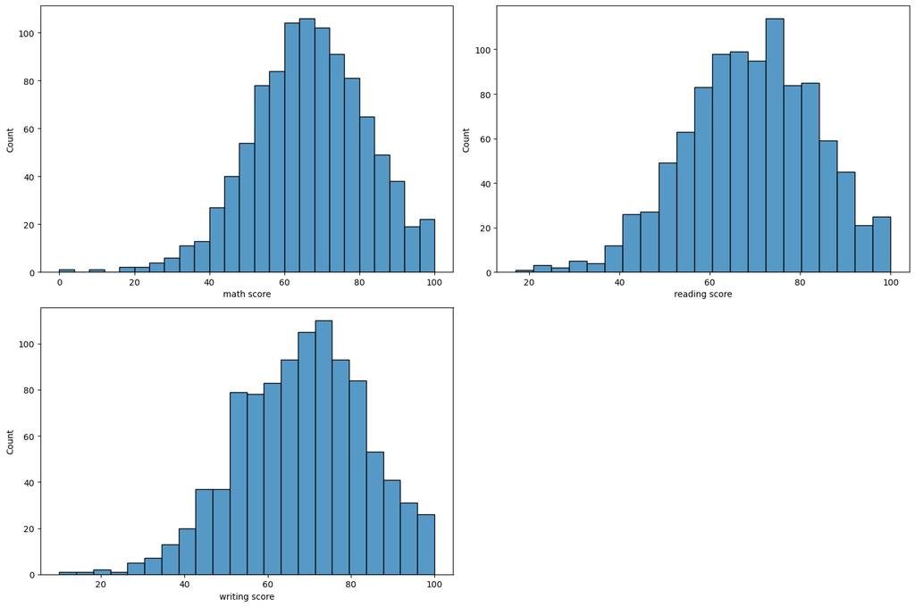

```python
plt.figure(figsize=(15,10))
plotnum=1
num_cols_to_plot = min(4, len(num_col))
for i in num_col[:num_cols_to_plot]:
  plt.subplot(2,2,plotnum)
  sns.histplot(sp[i])
  plotnum+=1
plt.tight_layout()
```

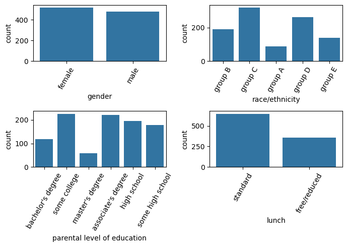

```python
plt.figure(figsize=(7,5))
plotnum=1
cat_cols_to_plot = min(4, len(cat_col))
for i in cat_col[:cat_cols_to_plot]:
  plt.subplot(2,2,plotnum)
  sns.countplot(x=i,data=sp)
  plt.xticks(rotation=60)
  plotnum+=1
plt.tight_layout()
```

## 2) Bivariate Analysis

In this bivariate analysis the numerical column will be analyse with categorical column

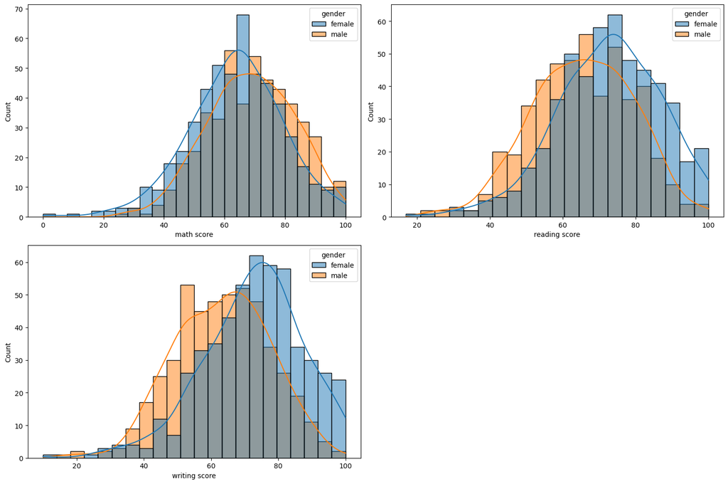

```python
plt.figure(figsize=(15,10))
plotnum=1
num_cols_to_plot = min(4, len(num_col))
for i in num_col[:num_cols_to_plot]:
  plt.subplot(2,2,plotnum)
  sns.histplot(x=i,data=sp,hue='gender',kde=True)
  plotnum+=1
plt.tight_layout()
```

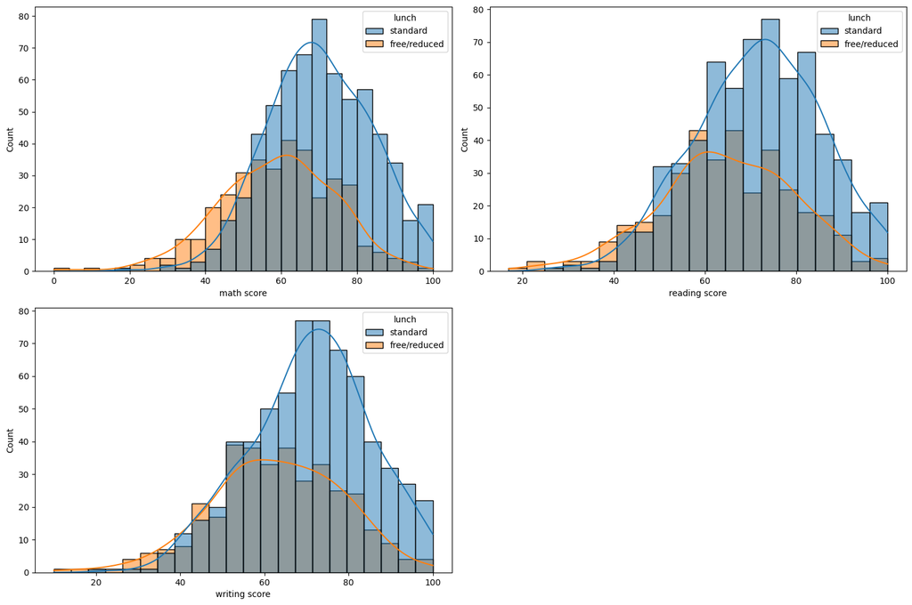

```python
plt.figure(figsize=(15,10))
plotnum=1
num_cols_to_plot = min(4, len(num_col))
for i in num_col[:num_cols_to_plot]:
  plt.subplot(2,2,plotnum)
  sns.histplot(x=i, data=sp,hue='lunch',kde=True)
  plotnum+=1
plt.tight_layout()
```

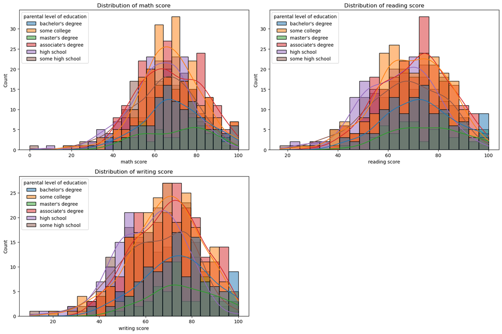

```python
plt.figure(figsize=(15, 10))
plotnum = 1
num_cols_to_plot = min(4, len(num_col))

for i in num_col[:num_cols_to_plot]:
    plt.subplot(2, 2, plotnum)
    sns.histplot(data=sp, x=i, hue='parental level of education', kde=True)
    plt.title(f'Distribution of {i}')
    plotnum += 1

plt.tight_layout()
plt.show()
```

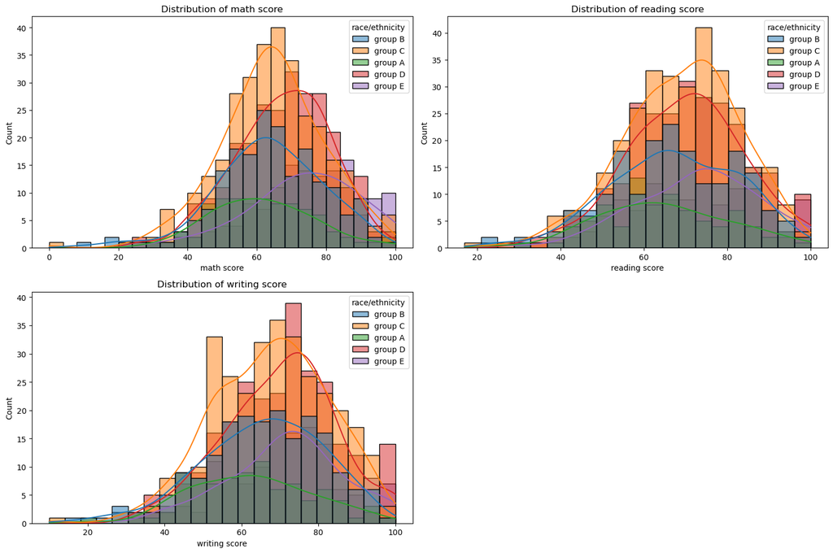

```python
plt.figure(figsize=(15, 10))
plotnum = 1
num_cols_to_plot = min(4, len(num_col))

for i in num_col[:num_cols_to_plot]:
    plt.subplot(2, 2, plotnum)
    sns.histplot(data=sp, x=i, hue='race/ethnicity', kde=True)
    plt.title(f'Distribution of {i}')
    plotnum += 1

plt.tight_layout()
plt.show()
```

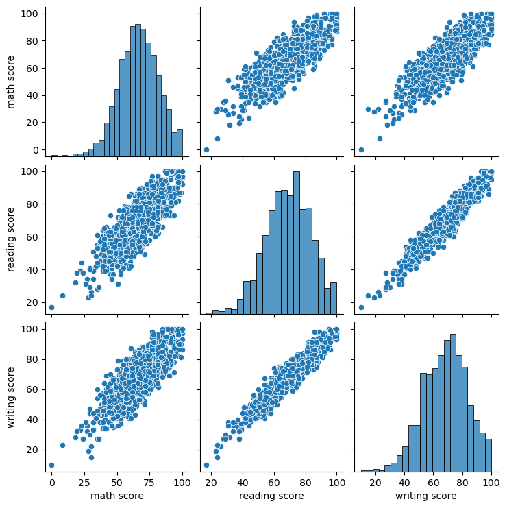

```python
sns.pairplot(sp)
```

# Data Cleaning

```python
sp.duplicated()
```

```
0      False
1      False
2      False
3      False
4      False
       ...
995    False
996    False
997    False
998    False
999    False
Length: 1000, dtype: bool
```

```python
sp.isnull().sum()
```

```
gender                         0
race/ethnicity                 0
parental level of education    0
lunch                          0
test preparation course        0
math score                     0
reading score                  0
writing score                  0
dtype: int64
```

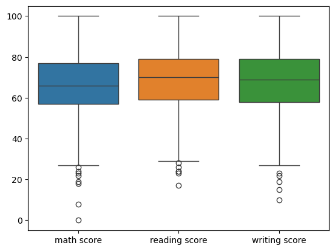

```python
sns.boxplot(sp)
```

```python
for i in num_col[:3]:
  Q1=sp[i].quantile(0.25)
  Q3=sp[i].quantile(0.75)
  IQR=Q3-Q1
  lower=Q1-1.5*IQR
  upper=Q3+1.5*IQR
  outliers=sp[(sp[i]<lower) | (sp[i]>upper)]
  print(f"{i} has {len(outliers)} outliers")
```

```
math score has 8 outliers
reading score has 6 outliers
writing score has 5 outliers
```

```python
outliers.head()
```

|  | gender | race/ethnicity | parental level of education | lunch | test preparation course | math score | reading score | writing score |
| --- | --- | --- | --- | --- | --- | --- | --- | --- |
| 59 | female | group C | some high school | free/reduced | none | 0 | 17 | 10 |
| 76 | male | group E | some high school | standard | none | 30 | 26 | 22 |
| 327 | male | group A | some college | free/reduced | none | 28 | 23 | 19 |
| 596 | male | group B | high school | free/reduced | none | 30 | 24 | 15 |
| 980 | female | group B | high school | free/reduced | none | 8 | 24 | 23 |

# INSIGHT FOR STUDENT PERFORMANCE IN EXAMS

📌 Key Insights—Student Performance in Exams

Lower parental education levels (e.g., high school or below) correlate with lower average student scores.

📚 3. Gender-Based Performance Trends Male students generally perform better in math, while female students tend to outperform in reading and writing.

This suggests potential gender-specific strengths and learning preferences.

🍔 4. Lunch Type Has a Noticeable Impact Students receiving standard lunch perform better than those with free/reduced lunch, indicating a possible link between nutrition and academic performance.

📘 5. Subject-wise Correlation There is a strong correlation between reading and writing scores — students who perform well in one tend to do well in the other.

Math has a moderate but still significant correlation with the other subjects.